# Reproducible research

2021-05-19

## Two Questions

1. What statistics do you think you need?
2. What do you find hard about data analysis?

## Course Contents

From data to paper:

1. Reproducible data analysis
2. Statistics

## Assumptions of Least Squares Regression

1. The relationship between the response and the predictors is ~linear.
2. The residuals have a mean of zero.
3. The residuals have constant variance (not heteroscedastic).
4. The residuals are independent (uncorrelated).
5. The residuals are normally distributed.

How to identify when these assumptions are violated.

What to do when these assumptions are violated.

## Statistics

- Exploratory data analysis
- Linear regression
- Analysis of variance with contrast matrices
- Generalised least-squares
- Non-linear least-squares
- Generalised linear models
- Generalised additive models
- Mixed effect models
- Introduction to Bayesian analysis

## Reproducible data analysis

- Is your current data analysis reproducible?
- Why is reproducible data analysis important?

## Tools for reproducible data analysis

- Use an integrated development environment (e.g. RStudio)
- Adopt an R style guide
- Getting help
- Version control with git
- Rmarkdown for dynamic documents
- Data handling with `tidyverse`

## Reproducibility Crisis

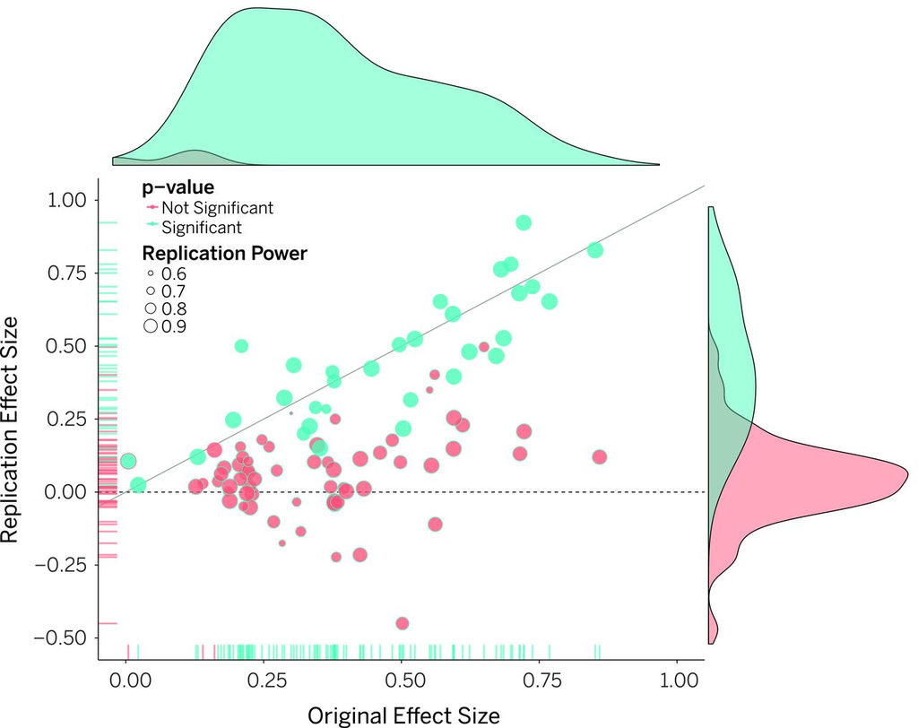

Estimating the reproducibility of psychological science [*Science*](https://science.sciencemag.org/content/349/6251/aac4716)

## Ocean Acidification and Fish Behaviour

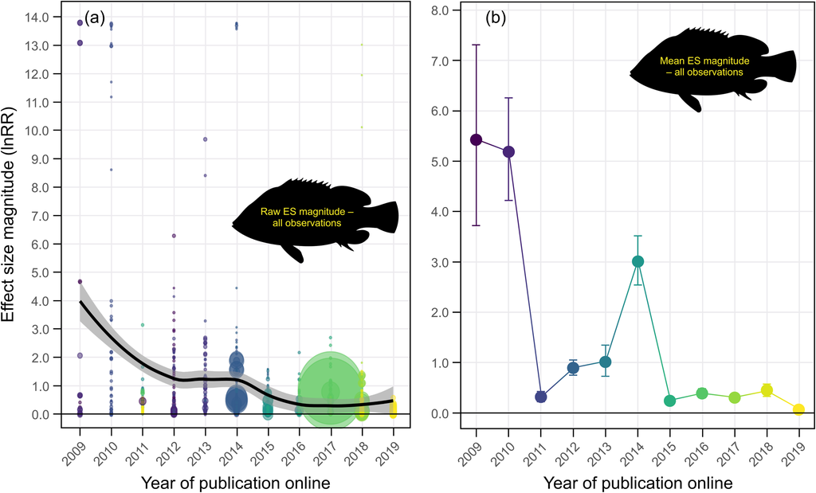

Meta-analysis reveals an extreme “decline effect” in the impacts of ocean acidification on fish behavior Clements et al 2022 [*PLOS Biology*](https://journals.plos.org/plosbiology/article?id=10.1371/journal.pbio.3001511)

## Most scientists ‘can’t replicate studies by their peers’

### Read

[Most scientists ‘can’t replicate studies by their peers’](http://www.bbc.com/news/science-environment-39054778)

[Bishop 2019. Rein in the four horsemen of irreproducibility](https://www.nature.com/articles/d41586-019-01307-2)

### Questions

- What is reproducibility?
- Why are papers non-reproducible
- Does this affect Biology?
- What is the role of statistics in reproducible analyses

[What does research reproducibility mean?](http://stm.sciencemag.org/content/8/341/341ps12.full)

Bad luck

- False Discovery

Questionable research practices

- HARKING
- p-Hacking
- Publication bias

Misconduct

- Fabrication, Falsification

## P-values

Often misinterpreted

- Not a measure of effect size or practical significance
- Not the probability that hypothesis is true
- Strongly affected by sample size

*If there were actually no effect (if the true difference between means were zero) then the probability of observing a value for the difference equal to, or greater than, that actually observed would be p=0.05.*

Many assumptions

## [Multiple testing](https://imgs.xkcd.com/comics/significant.png)

[figure not shown]

## False discovery rate

[figure not shown]

[Colquhoun 2014. An investigation of the false discovery rate and the misinterpretation of p-values](http://rsos.royalsocietypublishing.org/content/1/3/140216)

*If you use p=0.05 to suggest that you have made a discovery, you will be wrong at least 30% of the time. If, as is often the case, experiments are underpowered, you will be wrong most of the time*

[figure not shown]

## Choice of statistical methods

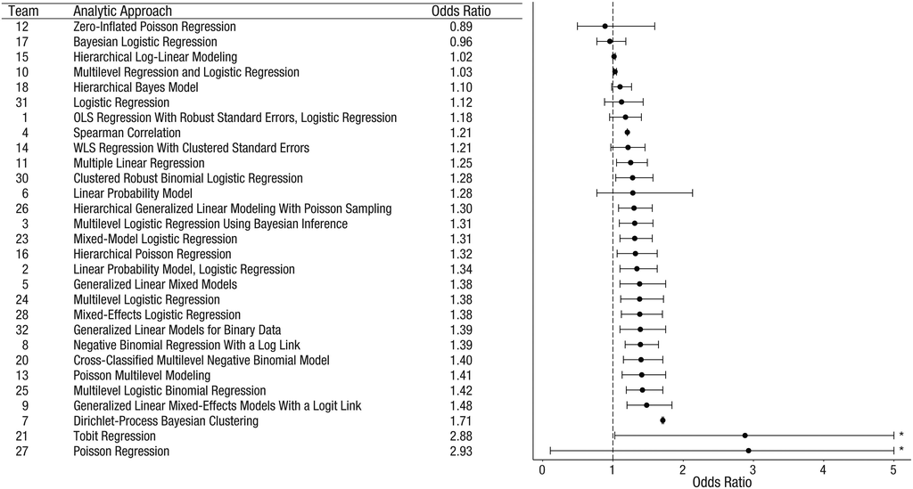

Silberzahn et al. (2018) Many Analysts, One Data Set: Making Transparent How Variations in Analytic Choices Affect Results. [*Advances in Methods and Practices in Psychological Science*](https://doi.org/10.1177/2515245917747646)

## Questionable research practices

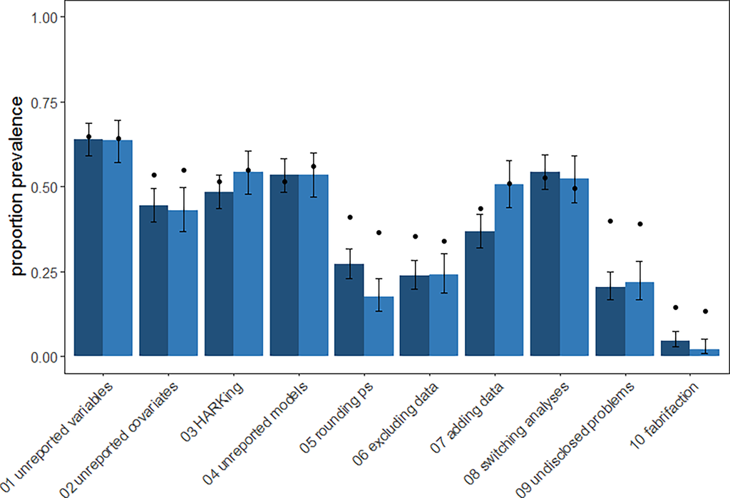

Fraser H et al (2018) Questionable research practices in ecology and evolution. [PLoS ONE](https://doi.org/10.1371/journal.pone.0200303)

## P-hacking

[Try P-hacking economic data](https://projects.fivethirtyeight.com/p-hacking/)

Predictors - US politicians

Response - Economic performance indicators

Other options

Find a significant positive and negative relationships between one party and the economy

## Garden of forking paths

Researcher degrees of freedom

Many decisions to be made

Can be difficult to predict in advance

[Gelman and Loken 2013](http://www.stat.columbia.edu/~gelman/research/unpublished/p_hacking.pdf)

## Publication bias

Can be more difficult to publish “negative” results

Explore publication bias with a shiny app.

In RStudio

- install `remotes` R package
- install `biostats.tutorials` package with `remotes::install_github("biostats-r/biostats.apps")`
- load `biostats.tutorials` package with `library()`
- run `publication_bias_app()`

The app simulates the effect of publication bias on the literature is only “significant” studies are published

## Misconduct?

Schiermeier (2017) Investigation finds Swedish scientists committed scientific misconduct. [*Nature*](https://www.nature.com/articles/d41586-017-08321-2)

Enserink (2021) Does ocean acidification alter fish behavior? Fraud allegations create a sea of doubt. [*Science*](https://www.sciencemag.org/news/2021/05/does-ocean-acidification-alter-fish-behavior-fraud-allegations-create-sea-doubt)

Viglione (2020) ‘Avalanche’ of spider-paper retractions shakes behavioural-ecology community [*Nature*](https://www.nature.com/articles/d41586-020-00287-y)

## Solutions

- Pre-registration
- Reproducible workflows
- Data management plans
- Archiving data and code

## Reproducible workflows

[video not shown]

https://laskowskilab.faculty.ucdavis.edu/2020/08/03/keeping-a-paper-trail-data-management-skills-for-reproducible-science/

## Data management plans

[Open Access to Research Data](https://www.uib.no/en/ub/111372/open-access-research-data)

Avoid the [stolen laptop scenario](https://retractionwatch.com/2021/05/03/ecologist-who-lost-thesis-awards-earns-expressions-of-concern-after-laptop-stolen/)

## Data archiving

- [Zenodo](https://zenodo.org/)
- [DataDryad](https://datadryad.org/stash)

Make data available to others.

## Code archiving

```
Starting January 1, 2022, The American Naturalist will require that any
analysis and simulation code (R scripts, Matlab scripts, Mathematica notebooks)
used to generate reported results be archived in a public repository
```

[American Naturalist](http://comments.amnat.org/2021/12/guidelines-for-archiving-code-with-data.html)

## General Reading

- Gillespie, C and Lovelace, R (2016) Efficient R programming. https://csgillespie.github.io/efficientR/
- Crawley, MJ (2012) The R Book. Wiley.
- Wickham, H. and Garrett Grolemund, G. (2017) R for Data Science https://r4ds.had.co.nz/
- Zuur AF et al (2009) Mixed effects models and extensions in ecology with R. Springer.